# QES Multi Factor Analysis

### Test the Improvement in Coverage of Analyst Expectation Factors

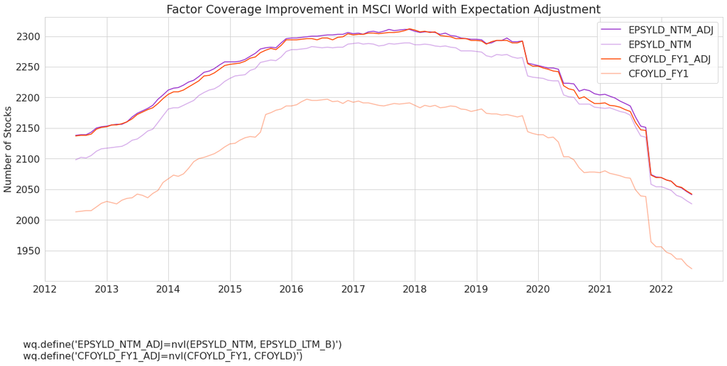

```python
factors_covg_adj = ['EPSYLD_NTM_ADJ', 'EPSYLD_NTM', 'CFOYLD_FY1_ADJ', 'CFOYLD_FY1']
factor_plot_params_map = {'EPSYLD_NTM_ADJ': [1.0, 'darkorchid'], 'EPSYLD_NTM': [0.4, 'darkorchid'], 'CFOYLD_FY1_ADJ': [1.0, 'orangered'], 'CFOYLD_FY1': [0.4, 'orangered']}

for factor in factors_covg_adj:
    df = data.element(factor).as_matrix().reset_index()

    cols = list(df.columns)[1:]
    nan_value_dict = {col: df[col].notnull().sum() for col in cols}
    factor_nan_values = pd.DataFrame.from_dict(nan_value_dict,  orient ='index').reset_index()
    factor_nan_values.columns = ['Date', 'Coverage']
    factor_nan_values['Date'] = pd.to_datetime(factor_nan_values['Date'])

    plt.plot(factor_nan_values['Date'], factor_nan_values['Coverage'], label = factor, alpha = factor_plot_params_map[factor][0], color = factor_plot_params_map[factor][1])

plt.title("Factor Coverage Improvement in MSCI World with Expectation Adjustment")
plt.ylabel("Number of Stocks")
plt.legend()

plt.figtext(0.1, -0.065, 'wq.define(\'EPSYLD_NTM_ADJ=nvl(EPSYLD_NTM, EPSYLD_LTM_B)\')')
plt.figtext(0.1, -0.099, 'wq.define(\'CFOYLD_FY1_ADJ=nvl(CFOYLD_FY1, CFOYLD)\')')
plt.show()
```

### Remove the low coverage factors from factor list

```python
#Define factors to remove from the Multi Factor Model
factors_to_remove = ['EPSYLD_NTM', 'CFOYLD_FY1']
factors = [f for f in alpha_factors if f not in factors_to_remove]

#Final list of factors
print ("Final list of factors in Multi-factor Model:\n")
pprint(factors)
```

```
Final list of factors in Multi-factor Model:

['EPSYLD_NTM_ADJ',
 'CFOYLD_FY1_ADJ',
 'DEBT_ASSET',
 'INT_COVER',
 'DEBT_EBIT',
 'MERTON',
 'ES_EPS_NTM_R3M',
 'ES_SALE_NTM_R3M',
 'REAL_VOL',
 'RTN12M']
```

# Factor Processing

### Create Point-in-time Investment Universe

```python
# This returns a handle to multi-factor analysis class
analytics = wq.multi_factor_analysis(data,  'IN_' + univ)

# Masking is needed to ensure we only keep factors in universe as non-NA
analytics.mask_factors(all_factors)
```

### Check Coverage of Factors in the Investment Universe

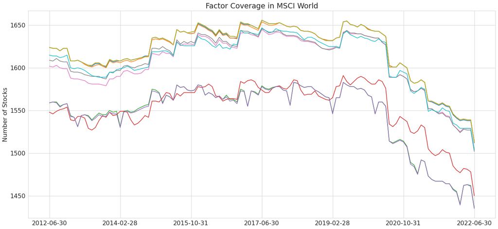

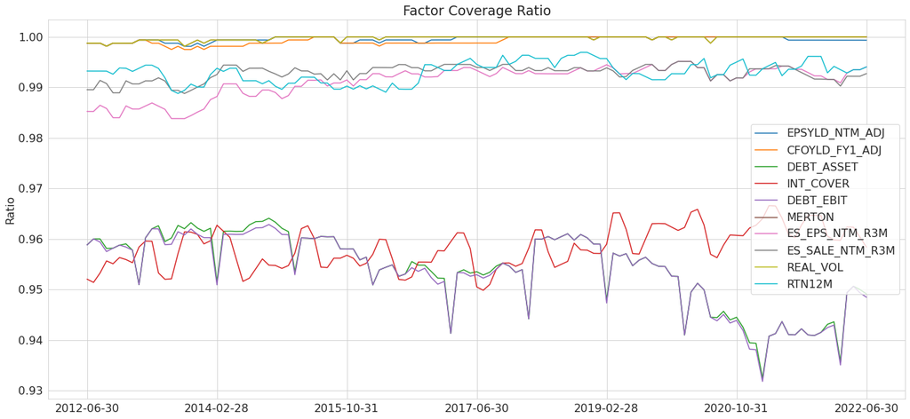

```python
coverage = pd.DataFrame({factor: data[factor].as_matrix().count() for factor in factors})
coverage_ratio = pd.DataFrame({factor: data[factor].as_matrix().count()/data['IN_' + univ].as_matrix().sum() for factor in factors}) # ratio of factor available
#%matplotlib inline
coverage.plot(title='Factor Coverage in MSCI World', figsize=(22, 10), legend=None)
plt.ylabel("Number of Stocks")
plt.show()

coverage_ratio.plot(title='Factor Coverage Ratio', figsize=(22, 10))
plt.ylabel("Ratio")
plt.show()
```

### Country Neutralization

Factor are neutralized within each Country since the Investment Universe is Global. Each neutralized variable is stored in the data object with the name specified as the first parameter

```python
# Neutralize all factors
for ff in all_factors:
    print('Neutralizing Factor ' + ff)
    analytics.basic_neutralize_factor('Neut_' + ff,ff,'z_normal','QES_COUNTRY')
```

```
Neutralizing Factor EPSYLD_NTM_ADJ
Neutralizing Factor CFOYLD_FY1_ADJ
Neutralizing Factor EPSYLD_NTM
Neutralizing Factor CFOYLD_FY1
Neutralizing Factor DEBT_ASSET
Neutralizing Factor INT_COVER
Neutralizing Factor DEBT_EBIT
Neutralizing Factor MERTON
Neutralizing Factor ES_EPS_NTM_R3M
Neutralizing Factor ES_SALE_NTM_R3M
Neutralizing Factor REAL_VOL
Neutralizing Factor RTN12M
Neutralizing Factor LOG_MKTCAP_ADJ
Neutralizing Factor BETA_LOCAL
```

#### Redefine factor names as Neutralized factors

```python
factors = ['Neut_' + factor for factor in factors]
risk_factors = ['Neut_' + factor for factor in risk_factors]
```

```python
risk_factors
```

```
['Neut_LOG_MKTCAP_ADJ', 'Neut_BETA_LOCAL']
```

### Size and Beta Neutralization of Alpha Factors using Multivariate Regression

Factors are the Neutralized against size and beta. This is to ensure that the factor and resulting model is not taking on too much size and beta exposure. This is accomplished regressing the normalized factor score to size and beta and then utilizing the residual as the resulting factor. Our research shows that this typically increases risk adjusted performance.

```python
#Neutralize all the alpha factors against the risk factors
for ff in factors:
    print('Neutralizing Factor ' + ff + ' against the risk factors')
    analytics.regress_multi_factor(ff, ff, risk_factors)
```

```
Neutralizing Factor Neut_EPSYLD_NTM_ADJ against the risk factors
Neutralizing Factor Neut_CFOYLD_FY1_ADJ against the risk factors
Neutralizing Factor Neut_DEBT_ASSET against the risk factors
Neutralizing Factor Neut_INT_COVER against the risk factors
Neutralizing Factor Neut_DEBT_EBIT against the risk factors
Neutralizing Factor Neut_MERTON against the risk factors
Neutralizing Factor Neut_ES_EPS_NTM_R3M against the risk factors
Neutralizing Factor Neut_ES_SALE_NTM_R3M against the risk factors
Neutralizing Factor Neut_REAL_VOL against the risk factors
Neutralizing Factor Neut_RTN12M against the risk factors
```

### Check cross-sectional factor distribution

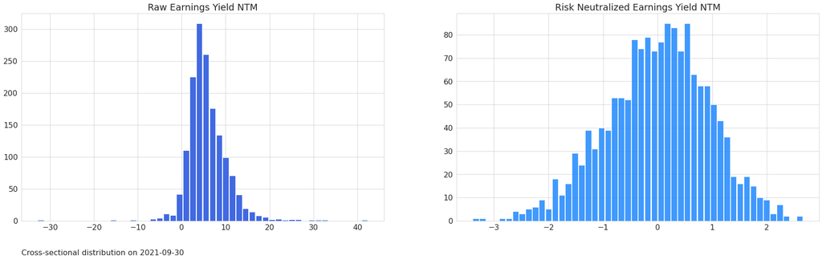

```python
factor = 'EPSYLD_NTM_ADJ'
date = '2021-09-30'

fig, axes = plt.subplots(ncols=2, figsize=(30,8))
ax = data.element(factor).as_matrix()[date].hist(rwidth=.9, bins=50, color='royalblue',ax=axes[0])
ax.set_title("Raw Earnings Yield NTM")

ax = data.element('Neut_' + factor).as_matrix()[date].hist(rwidth=.9, bins=50,color='#1080fe', alpha=.8, ax=axes[1])
_ = ax.set_title("Risk Neutralized Earnings Yield NTM")

plt.figtext(0.125, 0, "Cross-sectional distribution on " + date)
plt.show()
```

```python
import pandas as pd
country_region_map = pd.read_csv("/mnt/ebs1/data/config/country_regions.csv")
```

#### Inverting Vol, Debt to Asset, and Debt to Ebit as it is descending factor

```python
analytics.invert_factors(factors = ['Neut_REAL_VOL']) #you want to long low vol stocks and short high vol stocks
```

```
True
```

```python
analytics.invert_factors(factors = ['Neut_DEBT_EBIT'])
```

```
True
```

```python
analytics.invert_factors(factors = ['Neut_DEBT_ASSET'])
```

```
True
```

# Multi-factor Weighting and Composite factor construction

We have a python class that helps with doing different weightings. Prior to weighting the factor, we neutralize the factor. Here we demonstrate 4 different types of weighting

- Inverse Vol Weighted
- Risk Parity Weighted
- Equi Weighted
- Specified Constant Weighted

## 1. Inverse Volatility Weighting

Assigns more (less) weight to factor having lower (higher) standard deviation of Rank IC. Intuitively, a factor having high variability in predicting the future returns gets less weight and vice versa.

\begin{equation} \begin{split} &\Large w_{i, t} = \frac{\frac{1}{\sigma_{i, t}}}{\sum_{j=1}^{K} \frac{1}{\sigma_{j, t}}}, \\ \\ &\large \sigma_{i, t} = Standard\ Deviation\ of\ Rank\ IC\ of\ Factor\ i \end{split} \end{equation}

```python
# Vol weighting functions takes the set of factors as input.
volWeights = analytics.get_vol_weights('volWeights',factors)
volWeights.as_matrix()
```

|  | 2012-06-30 | 2012-07-31 | 2012-08-31 | 2012-09-30 | 2012-10-31 | 2012-11-30 | 2012-12-31 | 2013-01-31 | 2013-02-28 | 2013-03-31 | ... | 2021-09-30 | 2021-10-31 | 2021-11-30 | 2021-12-31 | 2022-01-31 | 2022-02-28 | 2022-03-31 | 2022-04-30 | 2022-05-31 | 2022-06-30 |
| --- | --- | --- | --- | --- | --- | --- | --- | --- | --- | --- | --- | --- | --- | --- | --- | --- | --- | --- | --- | --- | --- |
| Neut_EPSYLD_NTM_ADJ | NaN | NaN | NaN | NaN | NaN | NaN | NaN | NaN | NaN | NaN | ... | 0.055224 | 0.055782 | 0.056236 | 0.055111 | 0.051714 | 0.051886 | 0.052026 | 0.051758 | 0.050242 | 0.050226 |
| Neut_CFOYLD_FY1_ADJ | NaN | NaN | NaN | NaN | NaN | NaN | NaN | NaN | NaN | NaN | ... | 0.059795 | 0.060429 | 0.060905 | 0.059621 | 0.054351 | 0.054132 | 0.054295 | 0.054191 | 0.052816 | 0.052447 |
| Neut_DEBT_ASSET | NaN | NaN | NaN | NaN | NaN | NaN | NaN | NaN | NaN | NaN | ... | 0.164852 | 0.164065 | 0.166241 | 0.164811 | 0.172659 | 0.173056 | 0.172252 | 0.167437 | 0.166946 | 0.167750 |
| Neut_INT_COVER | NaN | NaN | NaN | NaN | NaN | NaN | NaN | NaN | NaN | NaN | ... | 0.119932 | 0.118461 | 0.116354 | 0.118665 | 0.117979 | 0.116893 | 0.117167 | 0.119495 | 0.120601 | 0.120995 |
| Neut_DEBT_EBIT | NaN | NaN | NaN | NaN | NaN | NaN | NaN | NaN | NaN | NaN | ... | 0.118725 | 0.118431 | 0.117084 | 0.121319 | 0.114932 | 0.114813 | 0.115191 | 0.115787 | 0.116801 | 0.117274 |
| Neut_MERTON | NaN | NaN | NaN | NaN | NaN | NaN | NaN | NaN | NaN | NaN | ... | 0.076924 | 0.076924 | 0.076692 | 0.077359 | 0.075130 | 0.074898 | 0.075132 | 0.075913 | 0.075687 | 0.075439 |
| Neut_ES_EPS_NTM_R3M | NaN | NaN | NaN | NaN | NaN | NaN | NaN | NaN | NaN | NaN | ... | 0.127573 | 0.130378 | 0.131576 | 0.133314 | 0.140759 | 0.141242 | 0.140989 | 0.143208 | 0.143150 | 0.142416 |
| Neut_ES_SALE_NTM_R3M | NaN | NaN | NaN | NaN | NaN | NaN | NaN | NaN | NaN | NaN | ... | 0.109767 | 0.109652 | 0.109823 | 0.109516 | 0.109706 | 0.110030 | 0.110324 | 0.110982 | 0.110940 | 0.110378 |
| Neut_REAL_VOL | NaN | NaN | NaN | NaN | NaN | NaN | NaN | NaN | NaN | NaN | ... | 0.101679 | 0.100868 | 0.099699 | 0.094597 | 0.093914 | 0.094008 | 0.094282 | 0.092449 | 0.093441 | 0.093672 |
| Neut_RTN12M | NaN | NaN | NaN | NaN | NaN | NaN | NaN | NaN | NaN | NaN | ... | 0.065527 | 0.065012 | 0.065390 | 0.065687 | 0.068857 | 0.069042 | 0.068341 | 0.068781 | 0.069376 | 0.069403 |

10 rows × 121 columns

The matrix returned by vol weight function is K x T, where K is number of factors and T is the number of time period

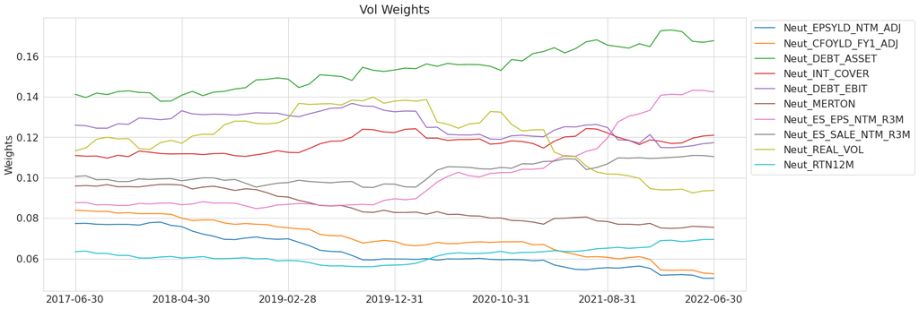

```python
volWeights.as_matrix().transpose().plot()
plt.legend(bbox_to_anchor=(1.0, 1.01))
plt.title('Vol Weights')
plt.ylabel('Weights')
plt.show()
```

We can then use these weights to compute the composites. Compute the weights using the vol weighting above. In below code, the composite is created (VolWeightedScore) using a weighted average of all the factor weights derived from Inverse Volatility Weighting.

\begin{equation} \begin{split} &\large w\_comp_{t} = \frac{\sum_{i=1}^{K} w_{i,t} * f_{i, t} }{\sum_{i=1}^{K} w_{i,t}} \end{split} \end{equation}

```python
x1 = analytics.multi_factor_score('VolWeightedScore',factors,'volWeights')
data.element('VolWeightedScore').as_matrix().head()
```

|  | 2012-06-30 | 2012-07-31 | 2012-08-31 | 2012-09-30 | 2012-10-31 | 2012-11-30 | 2012-12-31 | 2013-01-31 | 2013-02-28 | 2013-03-31 | ... | 2021-09-30 | 2021-10-31 | 2021-11-30 | 2021-12-31 | 2022-01-31 | 2022-02-28 | 2022-03-31 | 2022-04-30 | 2022-05-31 | 2022-06-30 |
| --- | --- | --- | --- | --- | --- | --- | --- | --- | --- | --- | --- | --- | --- | --- | --- | --- | --- | --- | --- | --- | --- |
| 062965.02 | NaN | NaN | NaN | NaN | NaN | NaN | NaN | NaN | NaN | NaN | ... | -0.065528 | 0.038713 | 0.080311 | 0.015075 | -0.086030 | -0.030069 | -0.030261 | -0.037428 | -0.076546 | -0.097124 |
| 158354.01 | NaN | NaN | NaN | NaN | NaN | NaN | NaN | NaN | NaN | NaN | ... | NaN | NaN | NaN | NaN | NaN | NaN | NaN | NaN | NaN | NaN |
| 005073.19 | NaN | NaN | NaN | NaN | NaN | NaN | NaN | NaN | NaN | NaN | ... | -0.599453 | -0.503077 | -0.358643 | -0.117334 | -0.369114 | -0.116752 | -0.193891 | -0.205720 | -0.530814 | -0.504029 |
| 264265.01 | NaN | NaN | NaN | NaN | NaN | NaN | NaN | NaN | NaN | NaN | ... | -0.517612 | -0.062112 | -0.553942 | -0.603736 | -0.813748 | -0.881281 | -0.724351 | -0.404687 | -0.858888 | -0.934112 |
| 260774.01 | NaN | NaN | NaN | NaN | NaN | NaN | NaN | NaN | NaN | NaN | ... | 0.404518 | 0.656316 | 0.602708 | 0.646583 | 0.270022 | 0.605296 | 0.545742 | 0.468569 | 0.231210 | 0.312901 |

5 rows × 121 columns

## 2. Risk Parity Weighting

## 2.1 Definition of marginal and total risk contributions

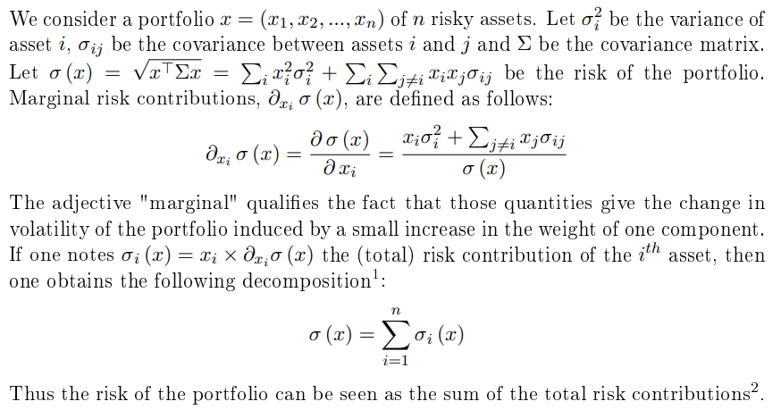

## 2.2 Specification of the Equal Risk Contribution (ERC) strategy

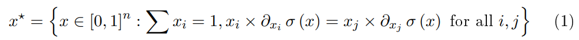

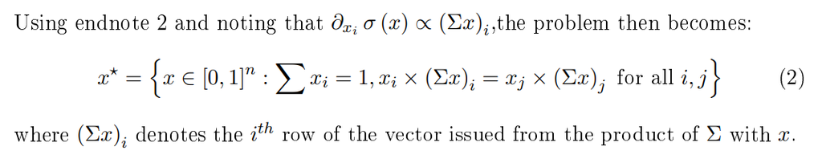

## 2.3 Numerical solutions to the ERC strategy

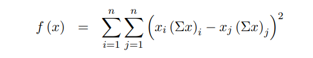

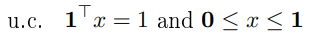

```python
# Risk parity weights take a bit longer as a complete covariance matrix
# is constructed for the investment universe. This is done over each rebalance period
riskParityWeights = analytics.get_risk_parity_weights_ic('riskParityWeights',factors)
```

```python
riskParityWeights.as_matrix()
```

|  | 2012-06-30 | 2012-07-31 | 2012-08-31 | 2012-09-30 | 2012-10-31 | 2012-11-30 | 2012-12-31 | 2013-01-31 | 2013-02-28 | 2013-03-31 | ... | 2021-09-30 | 2021-10-31 | 2021-11-30 | 2021-12-31 | 2022-01-31 | 2022-02-28 | 2022-03-31 | 2022-04-30 | 2022-05-31 | 2022-06-30 |
| --- | --- | --- | --- | --- | --- | --- | --- | --- | --- | --- | --- | --- | --- | --- | --- | --- | --- | --- | --- | --- | --- |
| Neut_EPSYLD_NTM_ADJ | NaN | NaN | NaN | NaN | NaN | NaN | NaN | NaN | NaN | NaN | ... | 0.068877 | 0.069025 | 0.070122 | 0.071085 | 0.070112 | 0.069745 | 0.069798 | 0.069474 | 0.068132 | 0.068066 |
| Neut_CFOYLD_FY1_ADJ | NaN | NaN | NaN | NaN | NaN | NaN | NaN | NaN | NaN | NaN | ... | 0.163424 | 0.165317 | 0.164479 | 0.153810 | 0.142010 | 0.143483 | 0.143165 | 0.140433 | 0.133808 | 0.127552 |
| Neut_DEBT_ASSET | NaN | NaN | NaN | NaN | NaN | NaN | NaN | NaN | NaN | NaN | ... | 0.107894 | 0.106230 | 0.110916 | 0.119319 | 0.124737 | 0.125134 | 0.126143 | 0.132255 | 0.130553 | 0.136207 |
| Neut_INT_COVER | NaN | NaN | NaN | NaN | NaN | NaN | NaN | NaN | NaN | NaN | ... | 0.070095 | 0.070326 | 0.069292 | 0.070294 | 0.073713 | 0.073096 | 0.073084 | 0.073858 | 0.073216 | 0.073165 |
| Neut_DEBT_EBIT | NaN | NaN | NaN | NaN | NaN | NaN | NaN | NaN | NaN | NaN | ... | 0.092051 | 0.092432 | 0.091194 | 0.095500 | 0.102247 | 0.102408 | 0.102425 | 0.103651 | 0.101713 | 0.100737 |
| Neut_MERTON | NaN | NaN | NaN | NaN | NaN | NaN | NaN | NaN | NaN | NaN | ... | 0.084103 | 0.084264 | 0.083606 | 0.085479 | 0.088420 | 0.088436 | 0.088363 | 0.087988 | 0.090627 | 0.097223 |
| Neut_ES_EPS_NTM_R3M | NaN | NaN | NaN | NaN | NaN | NaN | NaN | NaN | NaN | NaN | ... | 0.115843 | 0.116366 | 0.117695 | 0.117822 | 0.114152 | 0.112828 | 0.112537 | 0.112315 | 0.117549 | 0.115184 |
| Neut_ES_SALE_NTM_R3M | NaN | NaN | NaN | NaN | NaN | NaN | NaN | NaN | NaN | NaN | ... | 0.143280 | 0.141714 | 0.141205 | 0.141906 | 0.146320 | 0.146643 | 0.146746 | 0.144876 | 0.145929 | 0.135920 |
| Neut_REAL_VOL | NaN | NaN | NaN | NaN | NaN | NaN | NaN | NaN | NaN | NaN | ... | 0.087963 | 0.087363 | 0.085621 | 0.079878 | 0.077347 | 0.076543 | 0.076554 | 0.074905 | 0.080078 | 0.088261 |
| Neut_RTN12M | NaN | NaN | NaN | NaN | NaN | NaN | NaN | NaN | NaN | NaN | ... | 0.066470 | 0.066963 | 0.065871 | 0.064907 | 0.060942 | 0.061682 | 0.061184 | 0.060244 | 0.058395 | 0.057684 |

10 rows × 121 columns

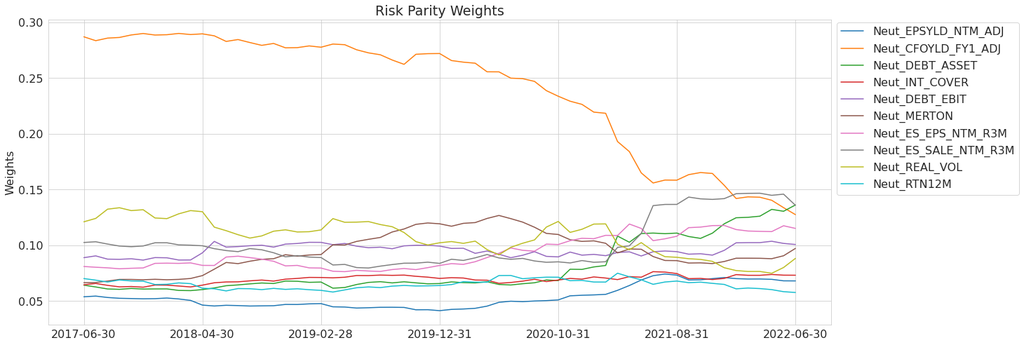

```python
riskParityWeights.as_matrix().transpose().plot()
plt.legend(bbox_to_anchor=(1.0, 1.01))
plt.title('Risk Parity Weights')
plt.ylabel('Weights')
plt.show()
```

```python
x1 = analytics.multi_factor_score('RiskParityWeightedScore',factors,'riskParityWeights')

# You can extract the weights as pandas data frame using as_matrix
data.element('RiskParityWeightedScore').as_matrix().head()
```

|  | 2012-06-30 | 2012-07-31 | 2012-08-31 | 2012-09-30 | 2012-10-31 | 2012-11-30 | 2012-12-31 | 2013-01-31 | 2013-02-28 | 2013-03-31 | ... | 2021-09-30 | 2021-10-31 | 2021-11-30 | 2021-12-31 | 2022-01-31 | 2022-02-28 | 2022-03-31 | 2022-04-30 | 2022-05-31 | 2022-06-30 |
| --- | --- | --- | --- | --- | --- | --- | --- | --- | --- | --- | --- | --- | --- | --- | --- | --- | --- | --- | --- | --- | --- |
| 062965.02 | NaN | NaN | NaN | NaN | NaN | NaN | NaN | NaN | NaN | NaN | ... | 0.006232 | 0.099225 | 0.150135 | 0.079444 | -0.085020 | -0.028128 | -0.018670 | 0.050394 | 0.025043 | 0.004633 |
| 158354.01 | NaN | NaN | NaN | NaN | NaN | NaN | NaN | NaN | NaN | NaN | ... | NaN | NaN | NaN | NaN | NaN | NaN | NaN | NaN | NaN | NaN |
| 005073.19 | NaN | NaN | NaN | NaN | NaN | NaN | NaN | NaN | NaN | NaN | ... | -0.426854 | -0.265469 | -0.140067 | 0.090727 | -0.143989 | 0.137746 | 0.095722 | 0.037304 | -0.273240 | -0.266750 |
| 264265.01 | NaN | NaN | NaN | NaN | NaN | NaN | NaN | NaN | NaN | NaN | ... | -0.586386 | -0.249458 | -0.639678 | -0.672937 | -0.866961 | -0.850099 | -0.694919 | -0.443953 | -0.897494 | -0.969804 |
| 260774.01 | NaN | NaN | NaN | NaN | NaN | NaN | NaN | NaN | NaN | NaN | ... | 0.231392 | 0.592312 | 0.557384 | 0.625440 | 0.201901 | 0.568644 | 0.528570 | 0.457832 | 0.208931 | 0.294525 |

5 rows × 121 columns

## 3. Equi-weighted

```python
x1 = analytics.multi_factor_score('EquiWeightedScore',
                                      factors,
                                     [1/len(factors)] * len(factors))

# You can extract the weights as pandas data frame using as_matrix
data.element('EquiWeightedScore').as_matrix().head()
```

|  | 2012-06-30 | 2012-07-31 | 2012-08-31 | 2012-09-30 | 2012-10-31 | 2012-11-30 | 2012-12-31 | 2013-01-31 | 2013-02-28 | 2013-03-31 | ... | 2021-09-30 | 2021-10-31 | 2021-11-30 | 2021-12-31 | 2022-01-31 | 2022-02-28 | 2022-03-31 | 2022-04-30 | 2022-05-31 | 2022-06-30 |
| --- | --- | --- | --- | --- | --- | --- | --- | --- | --- | --- | --- | --- | --- | --- | --- | --- | --- | --- | --- | --- | --- |
| 062965.02 | NaN | NaN | NaN | NaN | NaN | NaN | NaN | NaN | NaN | NaN | ... | 0.009700 | 0.112287 | 0.141598 | 0.086728 | 0.015993 | 0.048420 | 0.040027 | 0.059339 | 0.035429 | 0.012806 |
| 158354.01 | -0.131536 | 0.328012 | 0.335209 | 0.371924 | 0.519175 | 0.600040 | NaN | NaN | NaN | NaN | ... | NaN | NaN | NaN | NaN | NaN | NaN | NaN | NaN | NaN | NaN |
| 005073.19 | 0.176895 | 0.162611 | 0.175547 | 0.075438 | 0.294080 | 0.080654 | 0.183813 | -0.062200 | -0.140642 | -0.224081 | ... | -0.371436 | -0.301302 | -0.183438 | 0.043344 | -0.172038 | 0.051049 | 0.007243 | -0.015606 | -0.250710 | -0.229021 |
| 264265.01 | NaN | NaN | NaN | NaN | NaN | NaN | NaN | NaN | NaN | NaN | ... | -0.635925 | -0.349754 | -0.657928 | -0.728554 | -0.942795 | -0.912535 | -0.728477 | -0.511012 | -0.894660 | -0.942501 |
| 260774.01 | -0.325619 | -0.169131 | 0.024013 | -0.039007 | -0.090703 | -0.355628 | -0.365275 | -0.416406 | 0.067424 | 0.005137 | ... | 0.341982 | 0.626448 | 0.561549 | 0.631645 | 0.316708 | 0.560086 | 0.520185 | 0.456053 | 0.289807 | 0.346167 |

5 rows × 121 columns

## 4. Specified Weights

```python
x1 = analytics.multi_factor_score('SpecifiedWeightedScore',
                                      factors,
                                     [0.03, 0.05, 0.17, 0.02, 0.18, 0.15, 0.0, 0.2, 0.16, 0.04])

# You can extract the weights as pandas data frame using as_matrix
data.element('SpecifiedWeightedScore').as_matrix().head()
```

|  | 2012-06-30 | 2012-07-31 | 2012-08-31 | 2012-09-30 | 2012-10-31 | 2012-11-30 | 2012-12-31 | 2013-01-31 | 2013-02-28 | 2013-03-31 | ... | 2021-09-30 | 2021-10-31 | 2021-11-30 | 2021-12-31 | 2022-01-31 | 2022-02-28 | 2022-03-31 | 2022-04-30 | 2022-05-31 | 2022-06-30 |
| --- | --- | --- | --- | --- | --- | --- | --- | --- | --- | --- | --- | --- | --- | --- | --- | --- | --- | --- | --- | --- | --- |
| 062965.02 | NaN | NaN | NaN | NaN | NaN | NaN | NaN | NaN | NaN | NaN | ... | -0.020511 | 0.068700 | 0.129735 | 0.046997 | 0.006469 | 0.037989 | 0.029640 | 0.112856 | 0.093782 | 0.085733 |
| 158354.01 | -0.329068 | -0.073833 | 0.256045 | 0.319154 | 0.349082 | 0.280783 | NaN | NaN | NaN | NaN | ... | NaN | NaN | NaN | NaN | NaN | NaN | NaN | NaN | NaN | NaN |
| 005073.19 | 0.138415 | 0.180535 | 0.197994 | 0.071259 | 0.225682 | -0.058639 | -0.011549 | -0.231213 | -0.339428 | -0.288319 | ... | -0.752066 | -0.532443 | -0.589250 | -0.497023 | -0.645242 | -0.478139 | -0.424510 | -0.472807 | -0.637514 | -0.646736 |
| 264265.01 | NaN | NaN | NaN | NaN | NaN | NaN | NaN | NaN | NaN | NaN | ... | -0.334449 | 0.153621 | -0.467541 | -0.564682 | -0.662125 | -0.416414 | -0.209340 | 0.157314 | -0.614187 | -0.617966 |
| 260774.01 | -0.343929 | -0.269937 | -0.099079 | -0.156872 | -0.262506 | -0.467623 | -0.451311 | -0.375680 | 0.021197 | -0.072422 | ... | 0.257688 | 0.632639 | 0.542942 | 0.502464 | 0.078144 | 0.435109 | 0.424473 | 0.395286 | 0.162339 | 0.204638 |

5 rows × 121 columns

# Machine Learning based Factor Selection

```python
X_features_ls = []

for ff in factors:
    fac_mat = data.element(ff).as_matrix()
    X_features_ls.append(fac_mat.values)
```

### Input Feature: 3D Array

Process the z-normalized factor sets into 3-dimensional feature array: $$ feat\_num \times stock\_num \times dates $$

⚠️ remove the latest month as there is not forecast value (i.e., forward return)

```python
X_features_mat = np.stack(X_features_ls)[:,:,:-1]

print(X_features_mat.shape)
```

```
(10, 2470, 120)
```

## Target Variable Y

> Encode into boolean target variable. The natural output – future stock return that we try to predict – is still continuous. However, there are good reasons to translate the problem from continuous to discrete. Instead of forecasting stock returns, we convert the problem to **predicting outperformers versus underperformers** - we can classify the *top 30% stocks as outperformers* and similarly the *bottom 30% as underperformers*.

There are a number of reasons why such a transformation may be more desirable:

- The first motivation is that getting a point estimate of future stock return is extremely challenging, if not impossible. Models may overfit the data and may not be able to generalize to predict returns out-of-sample.
- On the other hand, classification problems tend to be more robust. In addition, some investors concern about hit rate (e.g., percentage of stocks with above or below average returns) more than the average. In particular, if a manager’s portfolio is highly concentrated, she can’t take advantage of a model with a great average return, but dominated by a few outliers.
- More importantly, a classification- based model is naturally different from a regression framework; therefore, provides diversification benefit.

```python
forward_rtn = data.element('FRTN1P').as_matrix()

def encode_target(rtn):
    """cross-sectional encoding function"""
    output_arr =  rtn.copy()
    output_arr[:] = np.NaN
    rtn_threshold = np.percentile(rtn[~np.isnan(rtn)], [30, 70])
    output_arr[rtn>rtn_threshold[1]] = 1
    output_arr[rtn<rtn_threshold[0]] = 0

    return output_arr

# continuous response variable
Y_rtn = forward_rtn.iloc[:,:-1]
Y_target = forward_rtn.iloc[:,:-1].apply(encode_target)
```

## Train-Validation-Test Split

- Training set: 2012 to 2016.
- Out-of-Sample Evaluation: 2017 onwards

```python
tot_dates = Y_target.columns

flag_date_train = tot_dates<"2017"
train_dates = tot_dates[tot_dates<"2017"]
flag_date_val = (tot_dates>"2017") & (tot_dates<"2019")
val_dates = tot_dates[flag_date_val]
test_dates = tot_dates[tot_dates>"2019"]

# keep the stocks having at least three factor with finite value
flag_feature_finite = (~np.isnan(X_features_mat[:,:, flag_date_train])).sum(0)>=3
flag_reg_train_mat = (~Y_rtn.loc[:,train_dates].isna()) & flag_feature_finite

# train Y
Y_reg_train = Y_rtn.loc[:,train_dates].values[flag_reg_train_mat]

# train X
X_reg_train = X_features_mat[:,:, flag_date_train][:,flag_reg_train_mat].T
X_reg_train[np.isnan(X_reg_train)] = 0
```

## ML Feature Selection

- ElasticNet linear regression uses the penalties from both LASSO and ridge techniques to regularize regression models.

  It is designed to solve the optimization of loss function by adding the following shrinkage term over the linear coefficients $\beta$:

  $$ \lambda \bigl[ \frac{1}{2} (1-\alpha) \; || \beta ||^2_2 + \alpha \; || \beta ||_1 \bigr] $$

  Due to the ridge regularization, the elastic net estimator *can handle correlations between the predictors* better than LASSO and due to the L1 regularization, *sparsity* is obtained.
- XGBoost stands for “Extreme Gradient Boosting”, where the term “Gradient Boosting” originates from the paper Greedy Function Approximation: A Gradient Boosting Machine, by Friedman.

## 1. ElasticNet Feature Selection

- **Elastic Net Model Hyperparameter**

  `alpha`: Shriankge term, defaults to 1.0. `alpha = 0` is equivalent to an ordinary least square

  ⚠️ Please note in sklearn's elastic net, the alpha parameter argument represents the $\lambda$ shrinkage coefficeint.

  `l1_ratio`: The ElasticNet mixing parameter. For `l1_ratio = 0` the penalty is an L2 penalty. For `l1_ratio = 1` it is an L1 penalty. For `0 < l1_ratio < 1`, the penalty is a combination of L1 and L2.

```python
enet_model = ElasticNet(random_state=0,
                        alpha=0.001,
                        fit_intercept=False)
```

```python
### fit the model
enet_model.fit(X_reg_train, Y_reg_train)
```

```
ElasticNet(alpha=0.001, fit_intercept=False, random_state=0)
```

### Linear Feature Importance

Absolute value of the fitted coeffcient for specific feature is regarded as the linear feature importance score of the factor.

```python
feat_importance = pd.DataFrame(enet_model.coef_,
                               index=factors,
                               columns=['Coef'])
```

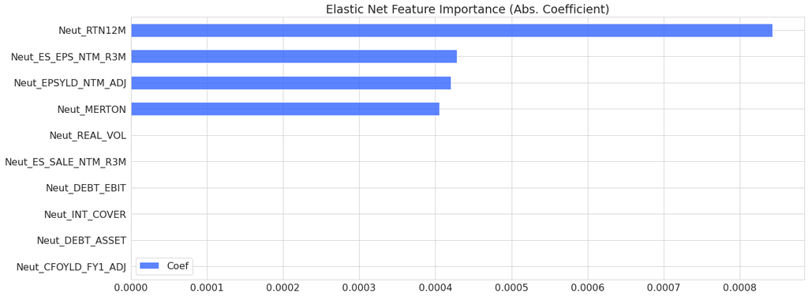

```python
feat_importance.abs().sort_values(by='Coef').plot(kind='barh', alpha=.8, color='#3366FF')
plt.title("Elastic Net Feature Importance (Abs. Coefficient)")
plt.legend()
plt.show()
```

## 2. XGBoost Feature Selection

```python
flag_train_mat = ~Y_target.loc[:,train_dates].isna()

# train Y
Y_train = Y_target.loc[:,train_dates].values[flag_train_mat]

# train X
X_train = X_features_mat[:,:, flag_date_train][:,flag_train_mat].T

print(" -- The training data is complete with [{}] number of training sample".format(len(Y_train)))

print("    => X variable shape {}".format(X_train.shape))
```

```
 -- The training data is complete with [73953] number of training sample
    => X variable shape (73953, 10)
```

```python
dtrain = xgb.DMatrix(X_train, label=Y_train, feature_names=factors)
```

- **XGBoost Model Hyperparameter**

  [ 📖 ] [Source Link](https://xgboost.readthedocs.io/en/stable/parameter.html)

  `max_depth`$d$ - *Maximum depth of a tree.* Increasing this value will make the model more complex and more likely to overfit. 0 indicates no limit on depth.

  `eta`$\eta$ - *Step size shrinkage used in update to prevents overfitting.* After each boosting step, we can directly get the weights of new features, and eta shrinks the feature weights to make the boosting process more conservative. By default set up tp 0.3.

  `gamma` $\gamma$ - *Minimum loss reduction required to make a further partition on a leaf node of the tree.* The larger gamma is, the more conservative the algorithm will be.

  `subsample` - *Subsample ratio of the training instances.* Setting it to 0.5 means that XGBoost would randomly sample half of the training data prior to growing trees. and this will prevent overfitting. Subsampling will occur once in every boosting iteration as a stochastic gradient descent.

```python
xgb_param = {'max_depth': 3,
             'subsample': 0.8,
             'objective': 'binary:logistic'}
```

Train the model

`bst` variable is the fitted XGBoost stock selection model

```python
%%time
bst = xgb.train(xgb_param, dtrain)
```

```
CPU times: user 9.74 s, sys: 0 ns, total: 9.74 s
Wall time: 321 ms
```

### Tree Model Feature Importance

**F score** - is a metric that simply sums up how many times each feature is split on.

[Source](https://stackoverflow.com/questions/34218245/how-is-the-feature-score-importance-in-the-xgboost-package-calculated)

```python
feature_score_dict = dict(zip(factors,
                              bst.get_fscore().values()))
```

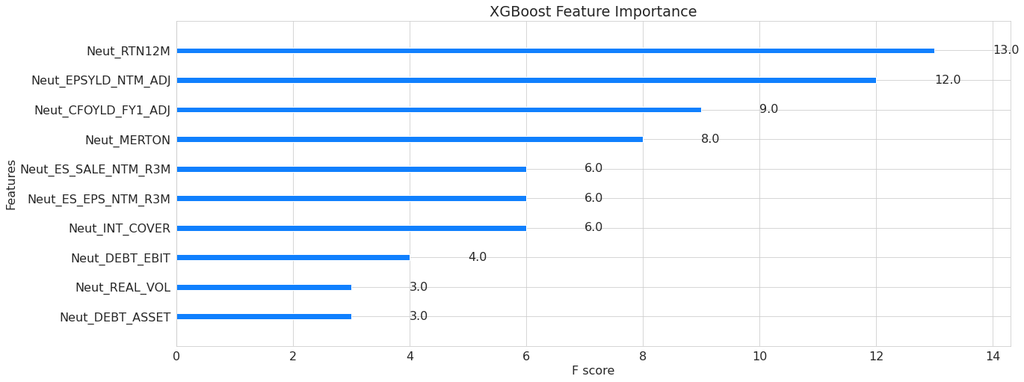

```python
xgb.plot_importance(feature_score_dict, color='#1080fe')
plt.title("XGBoost Feature Importance")
plt.show()
```

## XGBoost based Specified Multi-factor Weighting

```python
x1 = analytics.multi_factor_score('XGBoostWeightedScore',
                                      list(feature_score_dict.keys()),
                                      [x/sum(list(feature_score_dict.values())) for x in list(feature_score_dict.values())])

# You can extract the weights as pandas data frame using as_matrix
data.element('XGBoostWeightedScore').as_matrix().head()
```

|  | 2012-06-30 | 2012-07-31 | 2012-08-31 | 2012-09-30 | 2012-10-31 | 2012-11-30 | 2012-12-31 | 2013-01-31 | 2013-02-28 | 2013-03-31 | ... | 2021-09-30 | 2021-10-31 | 2021-11-30 | 2021-12-31 | 2022-01-31 | 2022-02-28 | 2022-03-31 | 2022-04-30 | 2022-05-31 | 2022-06-30 |
| --- | --- | --- | --- | --- | --- | --- | --- | --- | --- | --- | --- | --- | --- | --- | --- | --- | --- | --- | --- | --- | --- |
| 062965.02 | NaN | NaN | NaN | NaN | NaN | NaN | NaN | NaN | NaN | NaN | ... | 0.019283 | 0.152678 | 0.160936 | 0.116916 | 0.063712 | 0.087250 | 0.069344 | 0.092003 | 0.082602 | 0.055525 |
| 158354.01 | 0.076203 | 0.498250 | 0.459377 | 0.435947 | 0.640009 | 0.706677 | NaN | NaN | NaN | NaN | ... | NaN | NaN | NaN | NaN | NaN | NaN | NaN | NaN | NaN | NaN |
| 005073.19 | 0.219255 | 0.193801 | 0.213167 | 0.088680 | 0.364648 | 0.218894 | 0.321077 | 0.020216 | 0.036114 | -0.014716 | ... | -0.105469 | -0.082836 | 0.043433 | 0.290593 | 0.020600 | 0.240499 | 0.185925 | 0.183297 | -0.023270 | 0.009504 |
| 264265.01 | NaN | NaN | NaN | NaN | NaN | NaN | NaN | NaN | NaN | NaN | ... | -0.745989 | -0.636339 | -0.704220 | -0.799624 | -1.104531 | -0.970823 | -0.735712 | -0.626577 | -0.941869 | -0.959863 |
| 260774.01 | -0.275062 | -0.102421 | 0.138631 | 0.068263 | 0.001946 | -0.239550 | -0.238534 | -0.343832 | 0.189018 | 0.117143 | ... | 0.358417 | 0.630766 | 0.559072 | 0.699627 | 0.433298 | 0.570278 | 0.519801 | 0.444816 | 0.325206 | 0.371310 |

5 rows × 121 columns

## Exporting data to CSV File

```python
df = data.as_large_data_frame()
### Converting all data to pandas
df.to_csv('Multi-Factor-MSCI-World.csv',index=False)
```

## Backtesting all Factors including Composites

Each factor can be independently backtested or several factors can be backtested together.

```python
# Select factors to backtest
aggregate_factors = ['VolWeightedScore','RiskParityWeightedScore','EquiWeightedScore','SpecifiedWeightedScore', 'XGBoostWeightedScore']
all_active_factors = factors + aggregate_factors
NUM_BINS = 5


# The below code will backtest all the factors
# Arg1 List of factors
# Arg2 Number of Bins for backtest
backtest_results = analytics.backtest(all_active_factors, bins = NUM_BINS, align = False)
```

```python
#Backtest signal weighted
backtest_results2 = analytics.backtest(factors = aggregate_factors,
                                       bins = 0, align = False)

backtest_results2.factors = [f + '_SignalWeighted' for f in backtest_results2.factors]

backtest_results.backtest_results = backtest_results.backtest_results + backtest_results2.backtest_results
backtest_results.factors = backtest_results.factors + backtest_results2.factors
```

```python
#wq.env().run("save(data_1,file='lquant.RData')")
```

# Portfolio Optimization

There are 2 optimizers available in the LQuant environment.

### QES Optimizer

- The QES optimizer is a comprehensive optimizer that can handle different objective functions
  - MVO: Mean Variance Optimization
  - MRO: Mean Risk Optimization
  - maxAlpha: Maximum Alpha Optimization
  - minRisk: Minimum Risk Optimization
- The QES Optimizer can handle arbitrary long/short constraints
- The QES Optimizer can work with QES Risk Models as well as other risk models
- The QES Optimizer can have integer contraints
- The QES Optimizer can apply Neutralization constraints on Custom Factors as well as Risk Factors
- The QES Optimizer can use either standard or custom benchmarks
- The QES Optimizer can handle ADV constraint for both holding and trading
- The QES Optimizer can handle Turnover constraint
- The QES Optimizer is relatively slower than L2 Norm optimizer

### L2 Norm Optimizer (Fast)

- The L2 optimizer attempts to solve the weights that minimizes the L2 norm between the optimized weights and tracking weights
- The L2 optimizer can handle turnover constraints
- The L2 optimizer can handle hard to borrow constraints
- The L2 optimizer can handle custom neutralization constraints
- The L2 optimizer can handle turnover penalty
- The L2 optimizer only works for Long/Short portfolios

```python
run_optimization2('OPT_WEIGHT_NEW',5)
```

```python
backtest_results.factors
```

```python
### New Optimizer...
## bins not used. It is done to keep the signature consistent with the run_optimization function

def run_optimization2(name, bins):
    from lquantPy import LQOptimizer

    notional = OPTIMIZATION_CONTROLS.get('notional')
    tracker = OPTIMIZATION_CONTROLS.get('tracker')
    optimizer = LQOptimizer.QESOptimizer(template = 'default', name = 'opt', analytics = analytics)

    optimizer.set_long_short_benchmark(tracker)
    #"objective"= 'MVO', 'MVO', 'MRO', 'maxAlpha', 'minRisk'
    optimizer.set_objective('minRisk')

    neut_factors = OPTIMIZATION_CONTROLS.get('constraints').get('neut_risk')

    if neut_factors and len(neut_factors) > 0:
        optimizer.set_risk_neutralization_factor(neut_factors,
                                             factor_min_exposure = -0.05, factor_max_exposure = 0.05)
    optimizer.set_max_long_weight(1)
    optimizer.set_min_long_weight(1)
    optimizer.set_max_short_weight(1)
    optimizer.set_min_short_weight(1)
    optimizer.set_bounds(lb = -0.2, ub = 0.2)
    optimizer.set_notional_value(notional,notional)
    #optimizer.set_max_ADV_holding_participation(0.4)
    #optimizer.set_max_ADV_trading_participation(0.4)
    optimizer.set_adv_factor('ADV_1M_USD')
    optimizer.set_use_tcm(False)
    optimizer.summarize()

    if OPTIMIZATION_CONTROLS.get('constraints').get('hard_to_borrow'):
        optimizer.set_htb_threshold(1.0)


    if len(optimizer.msg()) > 0:
        print('Optimization failed due to ==> ' + optimizer.msg())
        return False

    optimizer.submit()

    optimizer.wait(3600)

    info = optimizer.info()
    status = info['status'].as_string()

    if status != 'SUCCESS':
        print('Optimization failed due to ==> ' + info['message'])
        return False

    optResult = optimizer.get_data()

    if optResult.is_error():
        print('Optimization failed due for date ==> ' + optResult.failed_date())
        return False

    optResult.append_weight_to_data(name)

    breq = wq.new_backtest_request()
    breq.forFactor(tracker)
    breq.weightFactor(name)
    opt_performance = wq.basic_backtest(data = data, req = breq)
    # Append to backtest_results
    backtest_results.backtest_results = backtest_results.backtest_results + [opt_performance]
    backtest_results.factors = backtest_results.factors + [name]
    return True
```